# Web Scraping : EveryNoise.com

EveryNoise.com’s Every Place At Once data for a few selected cities

Steve Carufel

First completed on April 12, 2019

# Main goal

This project aims to show which music genres are “particularly liked” by a couple of cities in the UK, and compare them. EveryNoise.com is a website that visualize Spotify’s streaming data on multiple dimensions. Every Place At Once looks at individual cities, for instance.

## How does the data looks like online

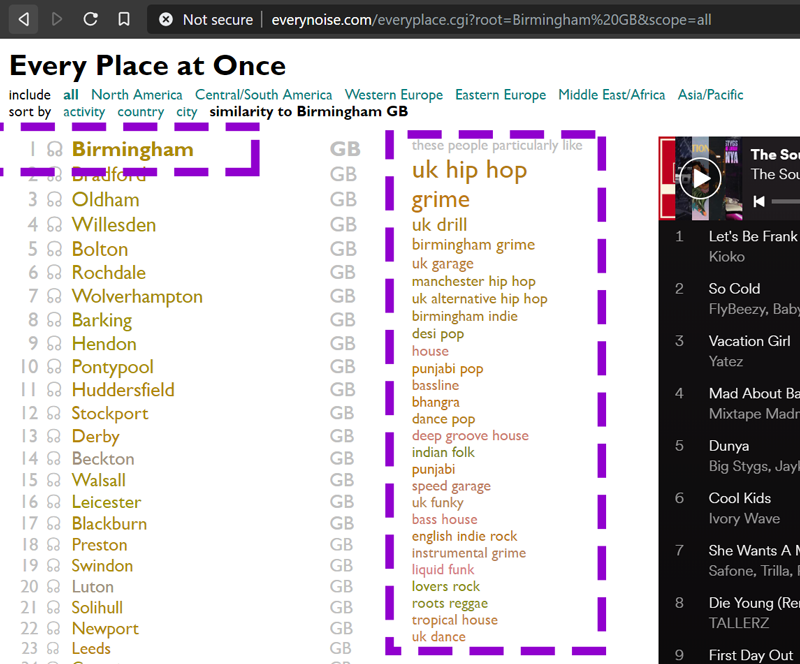

## The end result in R

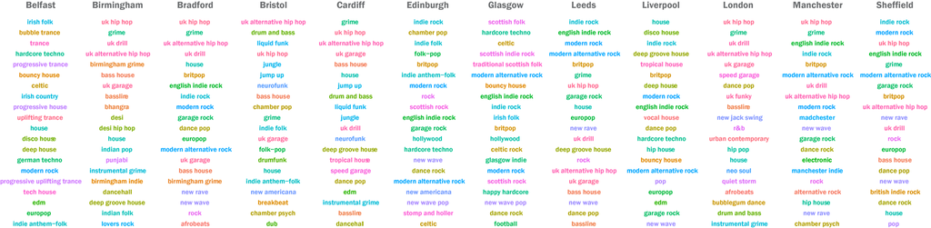

## The net end result for ths project (after playing with it in Illustrator)

[figure not shown]

## So let’s get going !

Loading the required packages…

```r
library(httr)
library(httpuv)
library(tidyverse)
library(showtext)
library(rlist)
library(rvest)
library(RColorBrewer)
library(colorRamps)
library(grDevices)
library(scales)
```

### For an easier understanding, I’ll start here with one city only. Birmingham sounds like a good one.

### Grabbing the html page from EveryNoise. This stores the html page’s code in R.

```r
BirminghamReaded <- read_html("http://everynoise.com/everyplace.cgi?root=Birmingham%20GB&scope=all")
```

#### Grabbing the genres specifically, CSS information was found by inspecting the items on the webpage (which can be done, in your web browser by right-clicking the text or data you want to grab and choose “Inspect” and then “Copy Selector” or something similar while looking at it selected in the page source code).

```r
BirminghamList <- html_text(html_node(BirminghamReaded, css = "div.note > div"))
print(BirminghamList) ### How our data looks like
```

```
## [1] "\nuk hip hop\ngrime\nuk drill\nbirmingham grime\nuk garage\nmanchester hip hop\nuk alternative hip hop\nbirmingham indie\ndesi pop\nhouse\npunjabi pop\nbassline\nbhangra\ndance pop\ndeep groove house\nindian folk\npunjabi\nspeed garage\nuk funky\nbass house\nenglish indie rock\ninstrumental …
```

#### A wild set of “/n” appears! So we’ll get rid of them, but first we’ll actually use them to separate our elements. In the *strsplit* function below, the argument “/n” is the separator - which characters are to be used to separate and distinguish our actual data.

```r
BirminghamGenresL <- strsplit(BirminghamList, "\n")
print(BirminghamGenresL)
```

```
## [[1]]
##  [1] ""                       "uk hip hop"
##  [3] "grime"                  "uk drill"
##  [5] "birmingham grime"       "uk garage"
##  [7] "manchester hip hop"     "uk alternative hip hop"
##  [9] "birmingham indie"       "desi pop"
## [11] "house"                  "punjabi pop"
## [13] "bassline"               "bhangra"
## [15] "dance pop"              "deep groove house"
## [17] "indian folk"            "punjabi"
## [19] "speed garage"           "uk funky"
## [21] "bass house"             "english indie rock"
## [23] "instrumental grime"     "liquid funk"
## [25] "lovers rock"            "roots reggae"
## [27] "tropical house"         "uk dance"
```

### Now it’s a list, but it will probably be more useful as a vector

```r
BirminghamGenresV <- unlist(BirminghamGenresL)
print(BirminghamGenresV)
```

```
##  [1] ""                       "uk hip hop"
##  [3] "grime"                  "uk drill"
##  [5] "birmingham grime"       "uk garage"
##  [7] "manchester hip hop"     "uk alternative hip hop"
##  [9] "birmingham indie"       "desi pop"
## [11] "house"                  "punjabi pop"
## [13] "bassline"               "bhangra"
## [15] "dance pop"              "deep groove house"
## [17] "indian folk"            "punjabi"
## [19] "speed garage"           "uk funky"
## [21] "bass house"             "english indie rock"
## [23] "instrumental grime"     "liquid funk"
## [25] "lovers rock"            "roots reggae"
## [27] "tropical house"         "uk dance"
```

#### Because our first few characters were “/n”, our first value is now an empty string, we can see it easily in the console so now we can just remove it by telling R to remove the first value in BirminghamGenresV

```r
BirminghamGenresV <- BirminghamGenresV[-1]
print(BirminghamGenresV)
```

```
##  [1] "uk hip hop"             "grime"
##  [3] "uk drill"               "birmingham grime"
##  [5] "uk garage"              "manchester hip hop"
##  [7] "uk alternative hip hop" "birmingham indie"
##  [9] "desi pop"               "house"
## [11] "punjabi pop"            "bassline"
## [13] "bhangra"                "dance pop"
## [15] "deep groove house"      "indian folk"
## [17] "punjabi"                "speed garage"
## [19] "uk funky"               "bass house"
## [21] "english indie rock"     "instrumental grime"
## [23] "liquid funk"            "lovers rock"
## [25] "roots reggae"           "tropical house"
## [27] "uk dance"
```

#### It works! We got ourselves a vector of music genres that are especially popular in Birmingham. Now we’ll create a function to do this for all of our big or medium cities of interest.

#### In what follows, we put everything we did above in one single function that does all the job.

#### Note that to do this for every city of interest, we need the URL of every city’s unique page. In this case, it is easy, because the URL acts like a set of parameters. In our URL above with Birmingham, we can simply replace it with another city name like “London” or “Leeds”. The city name is the only difference between our URLs.

```r
Cities <- c("London", "Birmingham", "Manchester", "Leeds", "Sheffield", "Glasgow", "Edinburgh", "Bristol", "Liverpool", "Bradford", "Cardiff", "Belfast")
```

```r
ParticularLikesFUN <- function(x) {
  City <- x # The function's main input is one single city, not all 12 of them
  City_EN_URL <- str_c("http://everynoise.com/everyplace.cgi?root=", City, "%20GB&scope=all", sep = "", collapse = NULL)
  City_Readed <- read_html(City_EN_URL)
  City_Genres <- html_text(html_node(City_Readed, css = "div.note > div"))
  City_GenreL <- strsplit(City_Genres, "\n")
  City_GenreV <- unlist(City_GenreL)
  City_GenreV <- City_GenreV[-1]
  City_GenreV <- City_GenreV[1:20]
  factor(City_GenreV)
  print(City_GenreV)
}
```

### Now we haven’t done the scraping just yet, we just defined the function that will do it.

### The function alone as designed can only do it to one single city, not all of them.

### To do it on all of them, we’ll of course use the apply function family.

```r
ParticularLikesAllCities <- lapply(Cities, ParticularLikesFUN)
```

```
##  [1] "uk hip hop"             "grime"
##  [3] "uk garage"              "uk drill"
##  [5] "speed garage"           "dance pop"
##  [7] "uk alternative hip hop" "uk funky"
##  [9] "afro dancehall"         "pop"
## [11] "r&b"                    "uk dancehall"
## [13] "urban contemporary"     "bassline"
## [15] "hip pop"                "house"
## [17] "neo soul"               "new jack swing"
## [19] "australian pop"         "bass house"
##  [1] "uk hip hop"             "grime"
##  [3] "uk drill"               "birmingham grime"
##  [5] "uk garage"              "manchester hip hop"
##  [7] "uk alternative hip hop" "birmingham indie"
##  [9] "desi pop"               "house"
```

[output cut: 90 more lines]

#### Now, we got all our music genres, and at first they look as if they were all part of the same vector, but no. The sum of them is a list because we used **lapply**, which generates lists, but our list *items* are vectors.

### Each item within our list represents a city, in the same order. So let’s identify them as such.

```r
names(ParticularLikesAllCities) <- Cities
print(ParticularLikesAllCities)
```

```
## $London
##  [1] "uk hip hop"             "grime"
##  [3] "uk garage"              "uk drill"
##  [5] "speed garage"           "dance pop"
##  [7] "uk alternative hip hop" "uk funky"
##  [9] "afro dancehall"         "pop"
## [11] "r&b"                    "uk dancehall"
## [13] "urban contemporary"     "bassline"
## [15] "hip pop"                "house"
## [17] "neo soul"               "new jack swing"
## [19] "australian pop"         "bass house"
##
## $Birmingham
##  [1] "uk hip hop"             "grime"
##  [3] "uk drill"               "birmingham grime"
```

[output cut: 113 more lines]

```r
CitiesLikes <- ParticularLikesAllCities # The variable was getting long to type every time so let's shorten its name
```

### Might be easier to make it a data.frame from now on.

```r
CitiesLikesDF <- as.data.frame(CitiesLikes)
print(CitiesLikesDF)
```

```
##                    London             Birmingham         Manchester
## 1              uk hip hop             uk hip hop         uk hip hop
## 2                   grime                  grime              grime
## 3               uk garage               uk drill         indie rock
## 4                uk drill       birmingham grime            britpop
## 5            speed garage              uk garage english indie rock
## 6               dance pop     manchester hip hop        modern rock
## 7  uk alternative hip hop uk alternative hip hop               rock
## 8                uk funky       birmingham indie           uk drill
## 9          afro dancehall               desi pop         madchester
## 10                    pop                  house        garage rock
## 11                    r&b            punjabi pop          dance pop
## 12           uk dancehall               bassline manchester hip hop
## 13     urban contemporary                bhangra     australian pop
## 14               bassline              dance pop        disco house
```

[output cut: 69 more lines]

```r
CitiesLikesTidy <- CitiesLikesDF %>% gather(City, Genre)
CitiesLikesTidyRank <- cbind(CitiesLikesTidy, Rank = 1:20) # Keeping track of their initial order (top = most particularly liked)
```

### Almost done. Visualizing the whole thing.

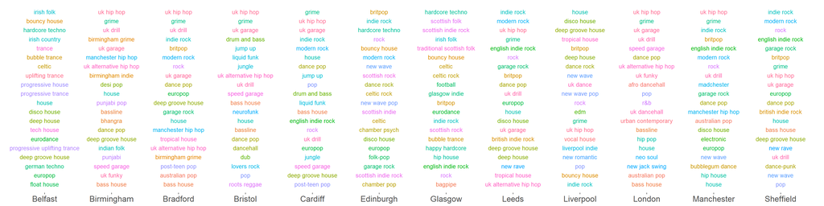

```r
CitiesLikesTidyRank %>%
  ggplot(aes(x = City, y = Rank)) +
  geom_text(aes(label = Genre, col = Genre), size = 3.5) +
  theme(
    legend.position = "none",
    axis.title.x = element_blank(),
    panel.background = element_blank(),
    axis.text.y = element_blank(),
    axis.title.y=element_blank(),
    axis.ticks.y=element_blank(),
    text = element_text(size = 18)
    ) +
  scale_y_reverse()
```